# Merging AOP L3 Tiles in R into Full-Site Rasters

Once you have generated full-site geotiffs, it is much simpler to visualize and conduct further analysis of the data in your preferred geospatial application, eg. ArcGIS, QGIS, or Google Earth Engine.

## Learning Objectives

After completing this activity, you will be able to:

- Run the `makeFullSiteMosaics` function to download and merge AOP L3 geotiff rasters, exporting the full site rasters to a geotiffs and COGs
- Read in and plot the full-site tiffs

## Things You’ll Need To Complete This Tutorial

To complete this tutorial you will need * The most current version of R and, preferably, RStudio installed on your computer. * A NEON API token (optional, but recommended). If you haven’t set up an API token, or used it in an R environment, please refer to the tutorial: [NEON API Tokens in R](https://www.neonscience.org/resources/learning-hub/tutorials/neon-api-tokens-tutorial) * You will need to install the following R packages, if they are not already installed:

### R Libraries to Install:

- **neonUtilities**: `install.packages('neonUtilities')`
- **gdalUtilities**: `install.packages('gdalUtilities')`
- **raster**: `install.packages('raster')`
- **data.table**: `install.packages('data.table')`
- **docstring**: `install.packages('docstring')`

### Data to Download

You do not need to download any data prior to running this tutorial, as you will download AOP data sets using `neonUtilities` as part of this lesson.

**Set Working Directory:** This lesson assumes that you have set your working directory to the folder where you have cloned the github repo, and/or where you have saved the aop_merge_raster_functions.R script (code can be downloaded at the bottom of this tutorial). You will need to modify the working directory path in this tutorial to match your local directory structure.

[An overview of setting the working directory in R can be found here.](https://www.neonscience.org/set-working-directory-r)

### Recommended Skills

For this tutorial you should be familiar with AOP data, and raster geotiff data generally. You should also be familiar with the `neonUtilities` R package for downloading NEON data.

### AOP Raster Data

The function `makeFullSiteMosaics` is set up for downloading AOP L3 raster data products. The table below shows a full list of these data products, including the sensor, data product ID (dpID), the sub-directory structure they are downloaded to (the neonUtilities function preserves the original folder structure), and the name of the files.

Refer to this table when using the function. If you select a dpID that is not in this list, the function will error out and display a table with the valid dpIDs, similar to this table.

| Sensor | Data Product ID | Download Path | Short Name |
| --- | --- | --- | --- |
| Camera | DP3.30010.001 | L3/Camera/Mosaic | image |
| Lidar | DP3.30024.001 | L3/DiscreteLidar/DTMGtif | DTM |
| Lidar | DP3.30024.001 | L3/DiscreteLidar/DSMGtif | DSM |
| Lidar | DP3.30015.001 | L3/DiscreteLidar/CanopyHeightModelGtif | CHM |
| Lidar | DP3.30025.001 | L3/DiscreteLidar/SlopeGtif | slope |
| Lidar | DP3.30025.001 | L3/DiscreteLidar/AspectGtif | aspect |
| Spectrometer | DP3.30011.001 | L3/Spectrometer/Albedo | albedo |
| Spectrometer | DP3.30012.001 | L3/Spectrometer/LAI | LAI |
| Spectrometer | DP3.30014.001 | L3/Spectrometer/FPAR | fPAR |
| Spectrometer | DP3.30019.001 | L3/Spectrometer/WaterIndices | WaterIndices |
| Spectrometer | DP3.30026.001 | L3/Spectrometer/VegIndices | VegetationIndices |

This tutorial illustrates the function for the NEON aquatic site [MCRA (McRae Creek)](https://www.neonscience.org/field-sites/mcra) in Domain 16, the Pacific Northwest. This site was chosen for demonstration because it is one of the smallest AOP sites, and therefore is quicker to download. Let’s get started!

First, clone the git repository locally and set the working directory to where you cloned the data skills repository.

```r
# change the wd depending on your local environment and where you cloned the repository or copied the aop_merge_raster_functions.R script
wd <- file.path(path.expand("~"),"GitHubRepos","NEON-Data-Skills","tutorials","R","AOP","AOP-L3-rasters")
setwd(wd)
```

First let’s use `source` to pull in the `aop_merge_raster_functions.R` script, which is located in the working directory. For more details on what `source` does, please refer to the [CU Earth Lab Tutorial on Source Functions in R](https://www.earthdatascience.org/courses/earth-analytics/multispectral-remote-sensing-data/source-function-in-R/)

```r
source("./aop_merge_raster_functions.R")
```

Let’s take a look a the documentation for the function `makeFullSiteMosaics`

```r
help(makeFullSiteMosaics)
```

You should see the function documentation pop up in the *RStudio Help* window, similar to below:

```
makeFullSiteMosaics {TempPackage}   R Documentation

Download all AOP files for a given site, year, and L3 product, mosaic the files, and save the full site mosaic to a tiff and cloud-optimized geotiff.

Description
This function 1) Runs the neonUtilities byFileAOP function to download NEON AOP data by site, year, and product (see byFileAOP documention for additional details). 2) mosaics the data product tiles into a full-site mosaic, as well as the associated error tifs, where applicable, and 3) saves the full…

Usage
makeFullSiteMosaics(
  dpID,
  year,
  siteCode,
  dataRootDir,
  outFileDir,
  apiToken = NULL
)

Arguments

dpID
The identifier of the AOP data product to download, in the form DP3.PRNUM.REV, e.g. DP3.30011.001. This works for all AOP L3 rasters except L3 reflectance. If an invalid data product ID is provided, the code will show an error message and display the valid dpIDs.

year
The four-digit year to search for data.

siteCode
The four-letter code of a single NEON site, e.g. 'MCRA'.

dataRootDir
The file path to download data to.

outFileDir
The file path where the full-site mosaic geotiffs and cloud-optimized geotiffs are saved.

apiToken
User specific API token (generated within neon.datascience user accounts). If not provided, no API token is used.
```

We recommend using an API token when downloading NEON data programmatically. The function will work without a token, if you leave it out (as described in the documentation), but it is best to get in the practice of using the token! Here I source it from a file, where the file consists of a single line of code defining the token (called NEON_TOKEN). Please refer to the R tutorial on generating tokens, linked in the requirements section at the beginning of this lesson if you have not already set up an API token.

```r
NEON_TOKEN <- "MY TOKEN"
```

We an read in the token using the source function as follows. This assumes the token is saved in the working directory, but you can also set the path to the token explicitly if you’ve saved it elsewhere.

```r
source(paste0(wd,"/neon_token.R"))
```

Now that we have a general idea of how this function works, from the documentation, let’s go ahead and run it, using our imported token. For this example, I set the download folder to ‘c:/neon/data’ and the output folder to ‘c:/neon/outputs/2021_MCRA/CHM/’. Modify these paths as desired according to your project structure.

Please heed the following warnings before you run the code:

WARNING: This function is currently set so that it does not check the file size before downloading. You can change this, if desired, by either removing the check.size parameter in the the `makeFullSiteMosaics` function, or changing the value for that setting to True (check.size=T). This will then stop the function and prompt you to type “y” or “n” to continue the download. We recommend changing this if you have limited storage space on your computer, but this will require a manual input to run the full function.

WARNING: We recommend extending the timeout value when downloading large AOP sites so the connection doesn’t stall out before the file finishes downloading. To change the timeout, you can use `options`, but be aware that this changes the computer’s settings outside of this R environment, so when you do this, be sure to change it back at the end. The default timeout is 60 seconds, we recommend changing to 300 seconds (5 minutes).

```r
timeout0 <- getOption('timeout')
print(timeout0)
```

```
## [1] 60
```

```r
options(timeout=300)
getOption('timeout')
```

```
## [1] 300
```

```r
download_folder<-'c:/neon/data'
chm_output_folder<-'c:/neon/outputs/2021_MCRA/CHM/'
```

```r
makeFullSiteMosaics('DP3.30015.001','2021','MCRA',download_folder,chm_output_folder,NEON_TOKEN)
```

Display the output files generated:

```r
list.files(chm_output_folder)
```

```
## [1] "2021_MCRA_2_CHM.tif"     "2021_MCRA_2_CHM_COG.tif"
```

Now we can read in and plot the full-site CHM tif that we generated using the raster package:

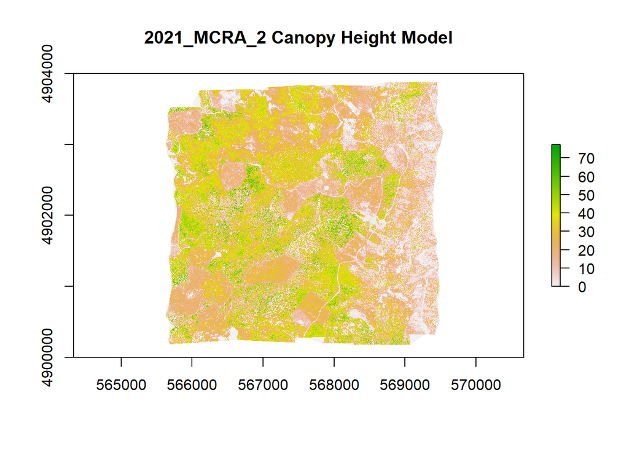

```r
MCRA_CHM <- raster(file.path(chm_output_folder,'2021_MCRA_2_CHM.tif'))
plot(MCRA_CHM,main="2021_MCRA_2 Canopy Height Model") # add title with main)
```

```r
veg_indices_output_folder<-'c:/neon/outputs/2021_MCRA/VegIndices/'
```

```r
makeFullSiteMosaics('DP3.30026.001','2021','MCRA',download_folder,veg_indices_output_folder,NEON_TOKEN)
```

Let’s see the full-site Veg Indices files that were generated using `list.files`:

```r
list.files(veg_indices_output_folder)
```

```
##  [1] "2021_MCRA_2_ARVI.tif"           "2021_MCRA_2_ARVI_COG.tif"
##  [3] "2021_MCRA_2_ARVI_error.tif"     "2021_MCRA_2_ARVI_error_COG.tif"
##  [5] "2021_MCRA_2_EVI.tif"            "2021_MCRA_2_EVI_COG.tif"
##  [7] "2021_MCRA_2_EVI_error.tif"      "2021_MCRA_2_EVI_error_COG.tif"
##  [9] "2021_MCRA_2_NDVI.tif"           "2021_MCRA_2_NDVI_COG.tif"
## [11] "2021_MCRA_2_NDVI_error.tif"     "2021_MCRA_2_NDVI_error_COG.tif"
## [13] "2021_MCRA_2_PRI.tif"            "2021_MCRA_2_PRI_COG.tif"
## [15] "2021_MCRA_2_PRI_error.tif"      "2021_MCRA_2_PRI_error_COG.tif"
## [17] "2021_MCRA_2_SAVI.tif"           "2021_MCRA_2_SAVI_COG.tif"
## [19] "2021_MCRA_2_SAVI_error.tif"     "2021_MCRA_2_SAVI_error_COG.tif"
```

Now we can read in the NDVI and NDVI error tifs:

```r
MCRA_NDVI <- raster(file.path(veg_indices_output_folder,'2021_MCRA_2_NDVI.tif'))
MCRA_NDVI_error <- raster(file.path(veg_indices_output_folder,'2021_MCRA_2_NDVI_error.tif'))
```

And, finally, let’s plot NDVI and NDVI error:

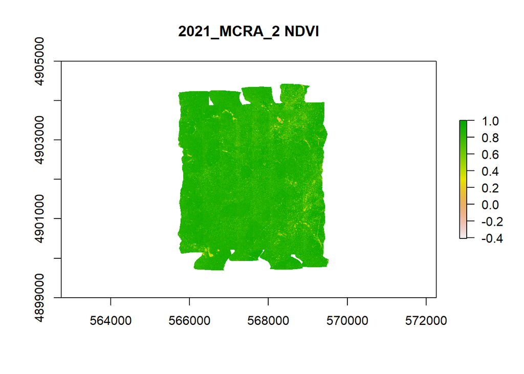

```r
plot(MCRA_NDVI,main="2021_MCRA_2 NDVI")
```

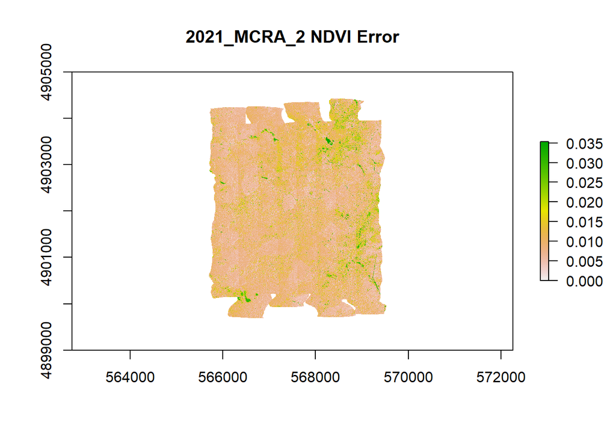

```r
plot(MCRA_NDVI_error,main="2021_MCRA_2 NDVI Error")
```

Looks good! Go ahead and try some different data products on your own, or a different site. Note that larger sites will take more time to download the data, and may require significant memory resources on your computer.

Last but not least, let’s change the timeout back to the original value:

```r
options(timeout=timeout0)
getOption('timeout')
```

```
## [1] 60
```